# hw4

Nan Chen

```r
# Access the Yarn cluster
options(scipen=200)
if (!require("pacman"))
  install.packages("pacman", repos = "http://cran.us.r-project.org/")
```

```r
library(pacman)
p_load("sparklyr", "dplyr", "ggplot2", "ggmap", "maps", "mapdata",
           "devtools", "ggrepel", "lubridate", "RColorBrewer")
Sys.setenv(SPARK_HOME="/usr/lib/spark")
config <- spark_config()
sc <- spark_connect(master = "yarn-client", config = config)
```

```r
# Connect the Hive tables
flights_tbl <- tbl(sc, 'flights')
airlines_tbl <- tbl(sc, 'airlines')
airports_tbl <- tbl(sc, 'airports')
```

```r
# Extract data in 2008
flights2008 <- flights_tbl %>% filter(origin != "Origin") %>%
  select(year, origin, dest) %>% filter(year == 2008)

airports <- airports_tbl %>% select(name, faa, lat, lon)

# Destination with # of flights
dest <- dplyr::left_join(flights2008, airports, by = c("dest" = "faa")) %>%
  group_by(dest) %>% summarise(n = n()) %>% collect() %>% arrange(desc(n)) %>%
  select("airport" = dest, n)

# Origin with # of flights
origin <- dplyr::left_join(flights2008, airports, by = c("origin" = "faa")) %>%
  group_by(origin) %>% summarise(n = n()) %>% collect() %>% arrange(desc(n)) %>%
  select("airport" = origin, n)
```

1. Map the top 10 busiest airports. Size of dots should reflect the number of flights through that destination.

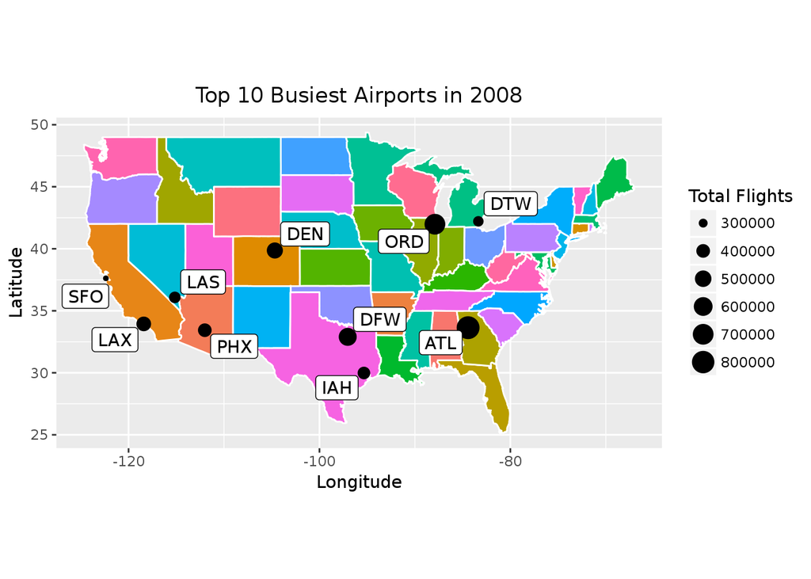

```r
# Add dest and origin together and print out top 10
combine <- bind_rows(dest, origin) %>%
  group_by(airport) %>% summarise(sum = sum(n)) %>% arrange(desc(sum)) %>%
  head(10)

# Pick out airports info for top 10
infotop10 <- airports %>% filter(faa %in% combine$airport) %>% collect()

# Complete info for top 10 airports
top10 <- left_join(combine, infotop10, by = c("airport" = "faa")) %>%
      transmute(airport = airport, totflights = sum, lat = as.numeric(lat),
                lon = as.numeric(lon), name = name)

usa <- map_data("usa")
states <- map_data("state")
ggplot() +
  theme(plot.title = element_text(hjust = 0.5)) +
  geom_polygon(data = states, aes(x = states$lon, y = states$lat, fill = region,
                                  group = group), color = "white") +
  geom_point(data = top10, aes(x = lon, y = lat, size = totflights)) +
  labs(x = "Longitude", y = "Latitude",
        title = "Top 10 Busiest Airports in 2008", size = "Total Flights") +
  geom_label_repel(data = top10, aes(x = lon, y = lat, label = airport)) +
  coord_fixed(1.3) + guides(fill = FALSE)
```

- According to the output, the busiest airport in 2008 is ATL, following by ORD, DFW, DEN, LAX, PHX, LAS, IAH, DTW, SFO.
2. Map the top 10 busiest direct routes. Size of lines should reflect the number of flights through that route.

```r
# Top 10 direct routes
route <- flights2008 %>% group_by(origin, dest) %>%
      summarise(n = n()) %>% collect() %>% arrange(desc(n)) %>%
      head(10)
# Destination and origin information
destinfo <- airports %>% filter(faa %in% route$dest) %>% collect()
dest10 <- left_join(route, destinfo, by = c("dest" = "faa"))

oriinfo <- airports %>% filter(faa %in% route$origin) %>% collect()
dest_ori <- left_join(dest10, oriinfo, by = c("origin" = "faa"))
dest_ori$scale <- (dest_ori$n / max(dest_ori$n))^10
dest_ori <- dest_ori %>% transmute(dest, lat.to = as.numeric(lat.x),
                      lat.from = as.numeric(lat.y), lon.to = as.numeric(lon.x),
                      lon.from = as.numeric(lon.y), n, scale)
# Airport info
comroute <- c(route$origin, route$dest)
route_airport <- as.data.frame(unique(comroute))
colnames(route_airport) <- "airport"

route_airport <- left_join(route_airport, oriinfo, by = c("airport" = "faa"))
```

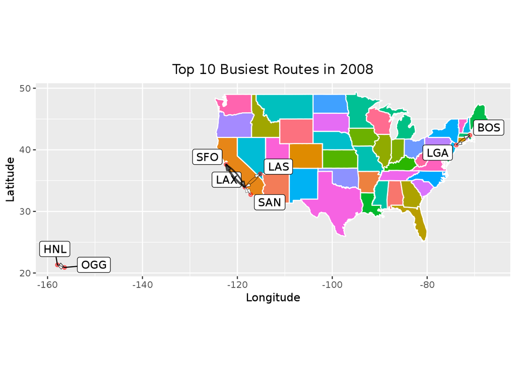

```r
route_airport <- route_airport %>% transmute(lon = as.numeric(lon),
                          lat = as.numeric(lat), airport, name)

usa <- map_data("usa")
states <- map_data("state")
ggplot() +
      geom_polygon(data = states, aes(x = long, y = lat, fill = region,
                            group = group), color = "white") +
      coord_fixed(1.3) + guides(fill=FALSE) +
      theme(plot.title = element_text(hjust = 0.5)) +
      geom_point(data = route_airport, aes(x = lon, y = lat), colour = "red",
                  alpha = 0.5) +
      labs(x = "Longitude", y = "Latitude",
             title = "Top 10 Busiest Routes in 2008") +
      geom_label_repel(data =  route_airport, aes(x = lon, y = lat),
                       label =  route_airport$airport) +
      geom_curve(data = dest_ori, aes(x = lon.from, y = lat.from,
                                      xend = lon.to, yend = lat.to),
                 arrow = arrow(angle = 15, ends = "first",
                               length = unit(0.2, "cm"), type = "closed"),
                 size = dest_ori$scale, alpha = 0.7,
                 curvature = 0.15, inherit.aes = TRUE)
```

- According to the output, the busiest route in 2008 is SFO-LAX.
3. LAX: (a). Reproduce above plot. Visualize and explain some prominent features you observe. For example, what happened at points 1-5?

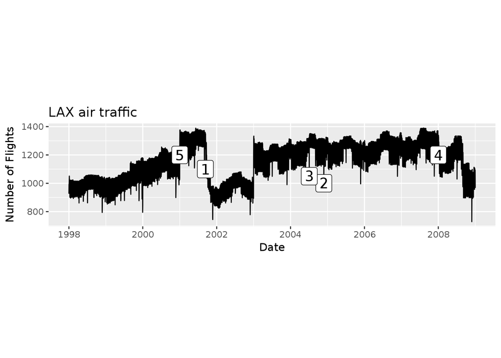

```r
flights_Q3 <- flights_tbl %>% select(year, month, dayofmonth, dayofweek,
      origin, dest) %>% filter(dest == "LAX" | origin == "LAX") %>%
      filter(year >= 1998 && year <= 2008)
air_traffic <- flights_Q3 %>%
      group_by(year, month, dayofmonth) %>%
      summarise(n = n()) %>%
      collect() %>%
      mutate(date = make_date(year = year, month = month, day = dayofmonth))

# Create 5 labels for the turning points
dates <- c("2001-09-11", "2004-11-25", "2004-07-04", "2008-01-01",
           "2001-01-01")
nf <- c(1100, 1000, 1050, 1200, 1200)
num_lab <- c("1", "2", "3", "4", "5")
labels <- data.frame(num_lab, dates, nf)

ggplot(air_traffic, aes(x = date, y = n)) +
  geom_line() +
  labs(x = "Date", y = "Number of Flights", title = "LAX air traffic") +
  geom_label(data = labels, aes(x = as.Date(dates, "%Y-%m-%d"), y = nf,
                                label = num_lab), size = 5) + coord_fixed(1.4)
```

- `Lable 1` drops dramatically mainly because of the terrorists attack thing. So people were scared of taking flights. `Lable 2` and `Lable 3` drops mainly because of the holidays. So people do not want to travel. `Lable 4` drops dramatically probably because of the global financial crisis. So people didn’t have too much money to spend on travelling around. `Lable 5` pops up a lot maybe due to a good economic environment. So people want to spend more money on travelling.

(b). Visualize and explain seasonal effects.

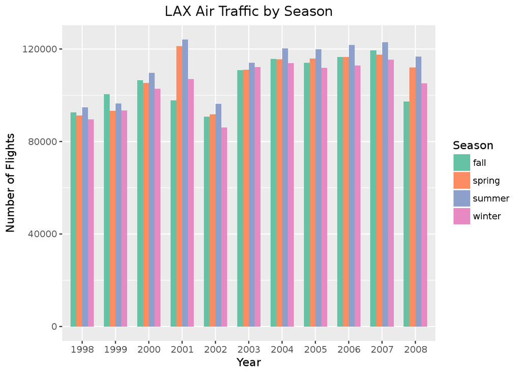

```r
flight_season <- flights_Q3 %>%
      mutate(season = if_else(month %in% c(12, 1, 2), "winter",
                              if_else(month %in% c(3, 4, 5), "spring",
                                      if_else(month %in% c(6, 7, 8), "summer",
                                              if_else(month %in% c(9, 10, 11),
                                                      "fall", "")
                                              )
                                      )
                              )
             ) %>%
      group_by(year, season) %>%
      summarise(n = n()) %>%
      collect()
ggplot(flight_season, aes(x = as.factor(year), y = n, fill = season)) +
  geom_col(stat = "identity", position = "dodge", width = 0.7) +
  theme(plot.title = element_text(hjust = 0.5)) +
  labs(x = "Year", y = "Number of Flights",
       title = "LAX Air Traffic by Season", fill = "Season") +
  scale_fill_brewer(palette = "Set2")
```

- According to the output, summer usually has the most air traffic at LAX across year 1998 to 2008.

(c). Visualize and explain weekly effects.

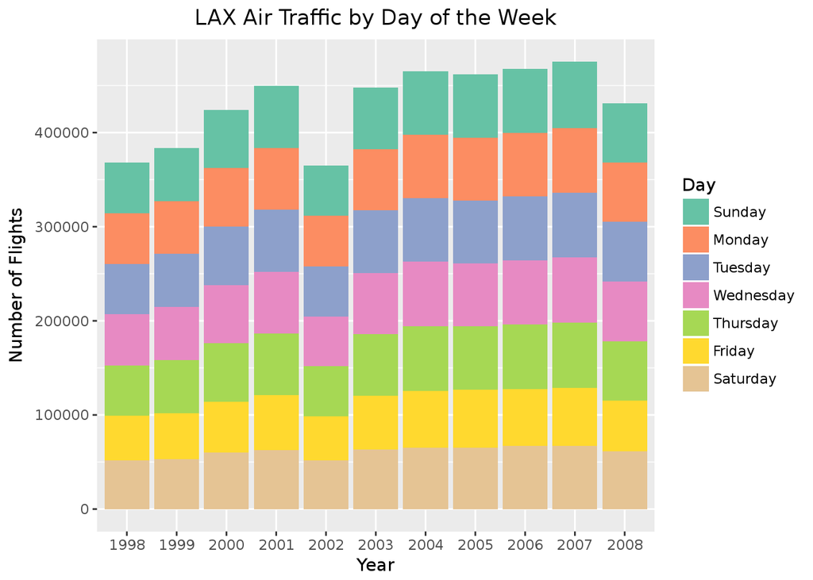

```r
flight_week <- flights_Q3 %>%
  group_by(year, dayofweek) %>%
  summarise(n = n()) %>%
  collect()
ggplot(flight_week, aes(x = as.factor(year), y = n,
                        fill = factor(dayofweek, labels = c("Sunday", "Monday", "Tuesday", "Wednesday",  "Thursday", "Friday", "Saturday")))) +
  geom_col() +
  labs(x = "Year", y = "Number of Flights", fill = "Day",
       title = "LAX Air Traffic by Day of the Week") +
  theme(plot.title = element_text(hjust = 0.5)) +
  scale_fill_brewer(palette = "Set2")
```

(d). Map top 10 destinations from LAX. Size of dots should reflect the number of flights from LAX to that destination.

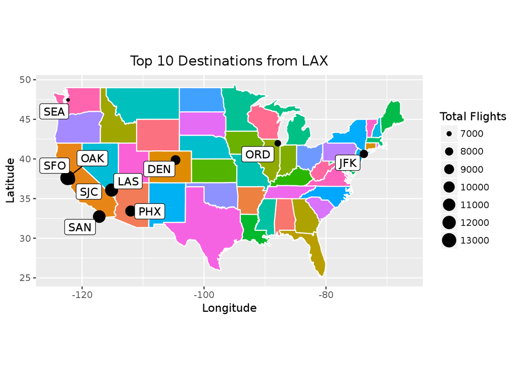

```r
LAX <- flights2008 %>% filter(origin == "LAX") %>% group_by(dest) %>%
      summarise(n = n()) %>% arrange(desc(n)) %>% collect()
destLAX <- airports %>% filter(faa %in% LAX$dest) %>% collect()
oriLAX <- left_join(destLAX, LAX, by = c("faa" = "dest")) %>%
  mutate(lat = as.numeric(lat), lon = as.numeric(lon)) %>%
  arrange(desc(n)) %>% collect() %>%
  head(10)

ggplot() +
  theme(plot.title = element_text(hjust = 0.5)) +
  geom_polygon(data = states, aes(x = states$lon, y = states$lat, fill = region,
                                  group = group), color = "white") +
  geom_point(data = oriLAX, aes(x = lon, y = lat, size = n)) +
  labs(x = "Longitude", y = "Latitude",
        title = "Top 10 Destinations from LAX", size = "Total Flights") +
  geom_label_repel(data = oriLAX, aes(x = lon, y = lat, label = faa)) +
  coord_fixed(1.3) + guides(fill = FALSE)
```

- The output shows that SFO is the first destinations travelling from LAX.
4. Build a predictive model for the arrival delay (`arrdelay`) of flights flying from LAX. Use the same filtering criteria as in the [lecture notes](http://hua-zhou.github.io/teaching/biostatm280-2018winter/slides/12-sparklyr/sparklyr-flights.html) to construct training and validation sets. You are allowed to use a maximum of 5 predictors. The prediction performance of your model on the validation data set will be an important factor for grading this question.

```r
model_data <- flights_tbl %>% filter(origin == "LAX") %>%
    filter(!is.na(arrdelay) & !is.na(depdelay) & !is.na(distance)) %>%
    filter(depdelay > 15 & depdelay < 240) %>%
    filter(arrdelay > -60 & arrdelay < 360) %>%
    filter(year >= 2003 & year <= 2007) %>%
    left_join(airlines_tbl, by = c("uniquecarrier" = "code")) %>%
    select(year, month, arrdelay, depdelay, distance, uniquecarrier,
           description)

# Summarize data by carrier
model_data %>%
  group_by(uniquecarrier) %>%
  summarize(description = min(description, na.rm = TRUE),
            arrdelay = mean(arrdelay, na.rm = TRUE),
            distance = mean(distance, na.rm = TRUE),
            depdelay = mean(depdelay, na.rm = TRUE)) %>%
  select(description, arrdelay, distance, depdelay) %>%
  arrange(arrdelay)
```

```
## # Source:     lazy query [?? x 4]
## # Database:   spark_connection
## # Ordered by: arrdelay
##    description                                  arrdelay distance depdelay
##    <chr>                                           <dbl>    <dbl>    <dbl>
##  1 Southwest Airlines Co.                           37.4     626.     41.5
##  2 Frontier Airlines Inc.                           41.1     782.     41.6
##  3 Envoy Air                                        42.1     233.     42.9
##  4 SkyWest Airlines Inc.                            42.4     254.     42.6
##  5 Delta Air Lines Inc.                             42.9    1931.     45.5
##  6 AirTran Airways Corporation                      43.1    1824.     46.0
##  7 US Airways Inc.                                  43.1    1383.     45.4
##  8 Alaska Airlines Inc.                             43.7     938.     46.5
##  9 Northwest Airlines Inc.                          43.8    1660.     47.7
## 10 America West Airlines Inc. (Merged with US …     45.3     702.     47.4
## # ... with more rows
```

```r
# Partition the data into training and validation sets
model_partition <- model_data %>%
  sdf_partition(train = 0.8, valid = 0.2, seed = 5555)

# Fit a linear model
ml1 <- model_partition$train %>%
    ml_linear_regression(arrdelay ~ distance + depdelay + uniquecarrier)

# Summarize the linear model
summary(ml1)
```

```
## Call: ml_linear_regression.tbl_spark(., arrdelay ~ distance + depdelay + uniquecarrier)
##
## Deviance Residuals (approximate):
##      Min       1Q   Median       3Q      Max
## -156.697   -7.098   -1.425    5.137  331.887
##
## Coefficients:
##      (Intercept)         distance         depdelay uniquecarrier_WN
##     -1.102945448     -0.002997948      1.013208722     -1.617943388
## uniquecarrier_OO uniquecarrier_AA uniquecarrier_UA uniquecarrier_DL
##      1.081415537      3.705256122      1.496089639      3.789641586
## uniquecarrier_AS uniquecarrier_MQ uniquecarrier_CO uniquecarrier_NW
##      0.384600881      0.502999647      5.209909863      1.311590117
## uniquecarrier_US uniquecarrier_HP uniquecarrier_XE uniquecarrier_F9
##      2.257369381      0.626563987      2.299379322      2.225035767
## uniquecarrier_TZ uniquecarrier_FL uniquecarrier_EV uniquecarrier_YV
##      5.601724369      3.141846050      1.212613042      0.699892920
## uniquecarrier_HA uniquecarrier_DH
##     -0.186566856     15.373470234
##
## R-Squared: 0.8851
## Root Mean Squared Error: 13.33
```

```r
# Get mse for valid
sdf_predict(ml1, model_partition$valid) %>%
  mutate(res = prediction - arrdelay) %>%
  summarise(mse = mean(res^2, na.rm = TRUE))
```

```
## # Source:   lazy query [?? x 1]
## # Database: spark_connection
##     mse
##   <dbl>
## 1  180.
```

- My model is arrdelay ~ distance + depdelay + uniquecarrier. The root mean squared error for train data is `13.33`; MSE for valid data is `179.91`.

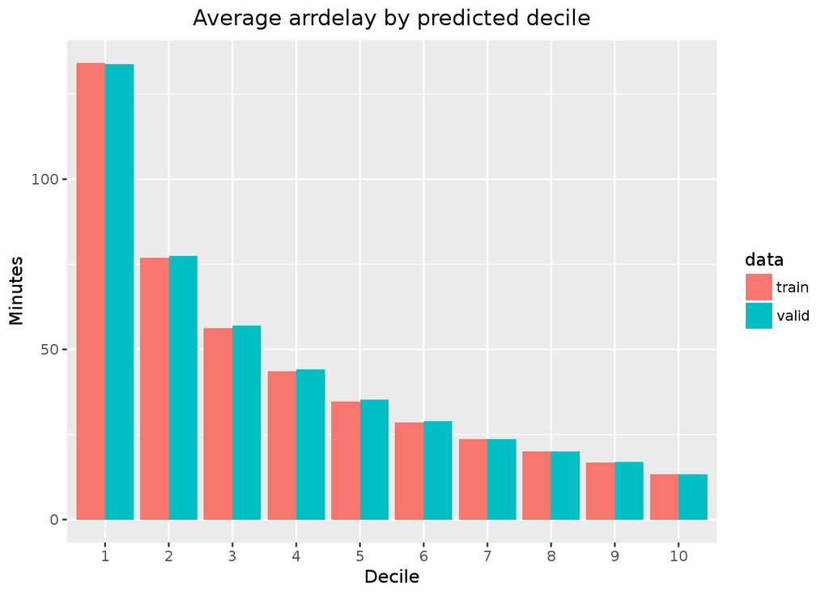

```r
# Assess model performance
# Calculate average arrdelay by predicted decile
model_deciles <- lapply(model_partition, function(x) {
    sdf_predict(ml1, x) %>%
      mutate(decile = ntile(desc(prediction), 10)) %>%
      group_by(decile) %>%
      summarize(arrdelay = mean(arrdelay, na.rm = TRUE)) %>%
      select(decile, arrdelay) %>%
      collect()
  })

# Create a summary dataset for plotting
deciles <- rbind(
  data.frame(data = 'train', model_deciles$train),
  data.frame(data = 'valid', model_deciles$valid),
  make.row.names = FALSE
)
# Plot average arrdelay by predicted decile
deciles %>%
  ggplot(aes(factor(decile), arrdelay, fill = data)) +
  theme(plot.title = element_text(hjust = 0.5)) +
  geom_bar(stat = 'identity', position = 'dodge') +
  labs(title = 'Average arrdelay by predicted decile', x = 'Decile',
       y = 'Minutes')
```

```r
# Predict performance
# Select data from an out of time sample
data_2008 <- flights_tbl %>% filter(origin == "LAX") %>%
  filter(!is.na(arrdelay) & !is.na(depdelay) & !is.na(distance)) %>%
  filter(depdelay > 15 & depdelay < 240) %>%
  filter(arrdelay > -60 & arrdelay < 360) %>%
  filter(year == 2008) %>%
  left_join(airlines_tbl, by = c("uniquecarrier" = "code")) %>%
  select(year, month, arrdelay, depdelay, distance, uniquecarrier, description,
         origin, dest)

# Summarize data by carrier
carrier <- sdf_predict(ml1, data_2008) %>%
  group_by(description) %>%
  summarize(arrdelay = mean(arrdelay, na.rm = TRUE),
            prediction = mean(prediction, na.rm = TRUE), freq = n()) %>%
  filter(freq > 100) %>%
  collect()

# Get mse for test
sdf_predict(ml1, data_2008) %>%
  mutate(res = prediction - arrdelay) %>%
  summarise(mse = mean(res^2, na.rm = TRUE))
```

```
## # Source:   lazy query [?? x 1]
## # Database: spark_connection
##     mse
##   <dbl>
## 1  203.
```

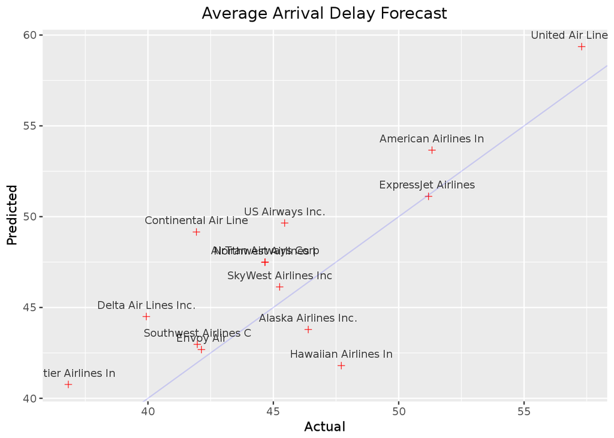

```r
# Plot actual arrdelay and predicted arrdelay by airline carrier
ggplot(carrier, aes(arrdelay, prediction)) +
  theme(plot.title = element_text(hjust = 0.5)) +
  geom_point(alpha = 0.75, color = 'red', shape = 3) +
  geom_abline(intercept = 0, slope = 1, alpha = 0.15, color = 'blue') +
  geom_text(aes(label = substr(description, 1, 20)), size = 3, alpha = 0.75,
            vjust = -1) +
  labs(title='Average Arrival Delay Forecast', x = 'Actual', y = 'Predicted')
```

- MSE for test data is `203.03`. It is very close to the validation mse, so I can say that overfitting is avoided.
5. Visualize and explain any other information you want to explore.

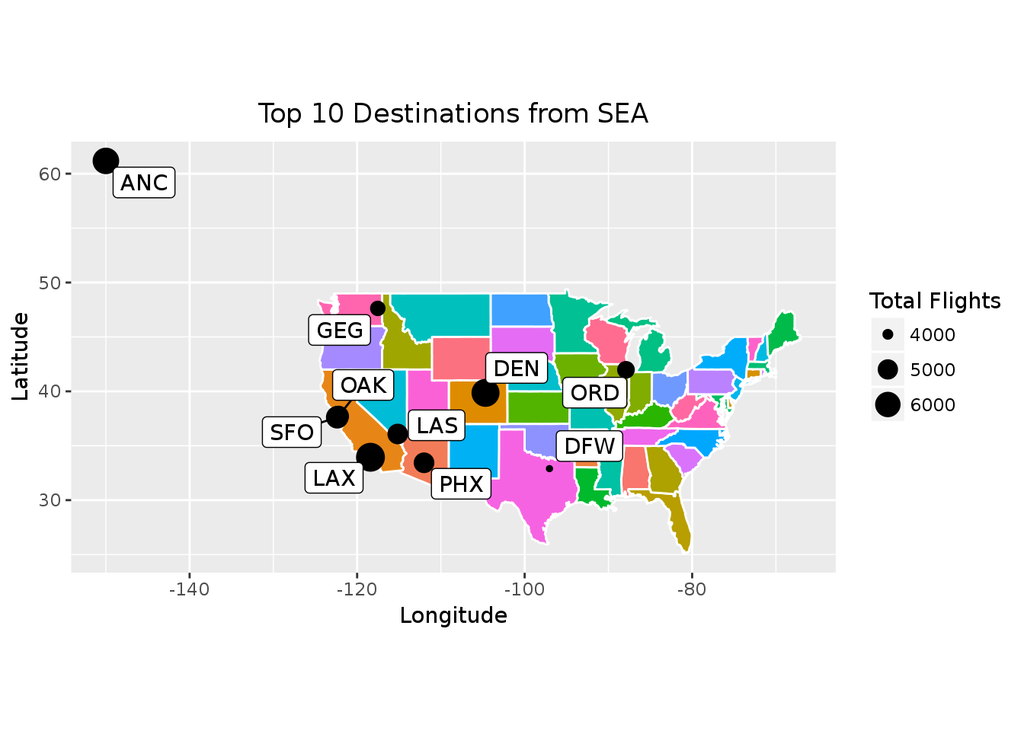

```r
SEA <- flights2008 %>% filter(origin == "SEA") %>% group_by(dest) %>%
      summarise(n = n()) %>% arrange(desc(n)) %>% collect()
destSEA <- airports %>% filter(faa %in% SEA$dest) %>% collect()
oriSEA <- left_join(destSEA, SEA, by = c("faa" = "dest")) %>%
  mutate(lat = as.numeric(lat), lon = as.numeric(lon)) %>%
  arrange(desc(n)) %>% collect() %>%
  head(10)

ggplot() +
  theme(plot.title = element_text(hjust = 0.5)) +
  geom_polygon(data = states, aes(x = states$lon, y = states$lat, fill = region,
                                  group = group), color = "white") +
  geom_point(data = oriSEA, aes(x = lon, y = lat, size = n)) +
  labs(x = "Longitude", y = "Latitude",
        title = "Top 10 Destinations from SEA", size = "Total Flights") +
  geom_label_repel(data = oriSEA, aes(x = lon, y = lat, label = faa)) +
  coord_fixed(1.3) + guides(fill = FALSE)
```

- The output shows that LAX is the first destinations travelling from SEA.